# Multivariate Analysis - pt.3

# 6장. 다변량 분산분석

# 다변량 일원배치 분산분석 - 예제1

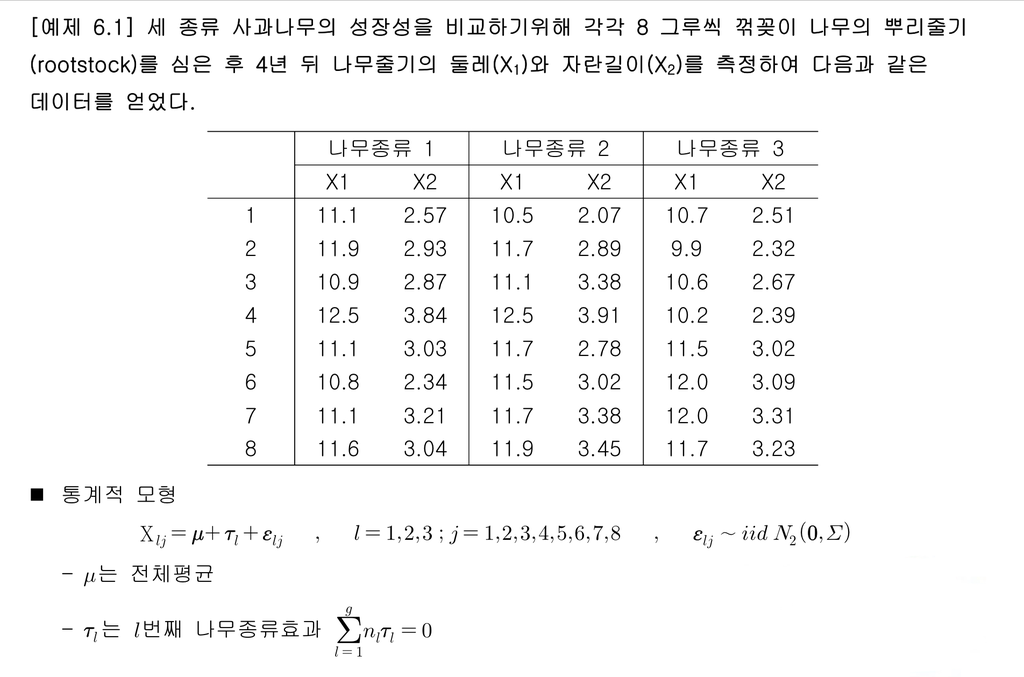

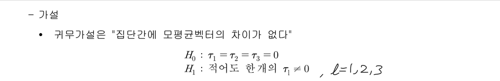

### Loading data

```r
rootstock <- read.table("/Users/jaeyonglee/Documents/College/Bachelor/uniwise/MVA/R/data/ch6/rootstock.txt", header=TRUE, sep="\t", skip=4)
rootstock
```

| Tree | X1 | X2 |
| --- | --- | --- |
| 1 | 11.1 | 2.57 |
| 1 | 11.9 | 2.93 |
| 1 | 10.9 | 2.87 |
| 1 | 12.5 | 3.84 |
| 1 | 11.1 | 3.03 |
| 1 | 10.8 | 2.34 |
| 1 | 11.1 | 3.21 |
| 1 | 11.6 | 3.04 |
| 2 | 10.5 | 2.07 |
| 2 | 11.7 | 2.89 |

[output cut: 14 more lines]

### 변수의 수

```r
p <- dim(rootstock[,-1])[2]
p
```

```
[1] 2
```

### 처리(집단) 수

```r
g <- length(table(rootstock$Tree))
g
```

```
[1] 3
```

### 처리별(집단별) 표본의 수

```r
n <- table(rootstock$Tree)   # table()에 예를 들어 1,1,1,1,2,2,2,2 이런식의 값이 들어가면 1: 4개, 2: 4개 머 이런식으로 값을 줌
n
```

```
1 2 3
8 8 8
```

#### 여기서 n[i]가 n_l을 나타내는거임

### 전체 자료의 수

```r
N <- sum(n)
N
```

```
[1] 24
```

### 처리별 평균벡터

```r
m <- aggregate(.~Tree, data=rootstock, mean)[,-1]  # .으로 rootstock의 모든 변수들을 ~Tree로 Tree별로, mean으로 평균을, [,-1]로 첫번째 열인 Tree를 빼줌(이건 그냥 범주형 변수이므로)
m <- as.matrix(m)
m
```

```
         X1      X2
[1,] 11.375 2.97875
[2,] 11.575 3.11000
[3,] 11.075 2.81750
```

#### 여기서 m[i,]가 xbar_i를 나타내는거임

### 전체 평균벡터

```r
tm <- colMeans(rootstock[,-1])  # 첫번째 열은 집단을 나타내는 범주형 변수라 필요없음
tm
```

```
      X1       X2
11.34167  2.96875
```

#### 이게 xbar를 나타내는거임

### 처리제곱합행렬

```r
B <- diag(0, p)  # Initialize; 걍 diag()으로 행렬만드는게 편해서 이걸로 한듯?
for(i in 1:g){
  B <- B+n[i]*(m[i,]-tm) %*% (t(m[i,]-tm))
}
B
```

```
           X1       X2
[1,] 1.013333 0.589000
[2,] 0.589000 0.343425
```

#### 여기서 n[i]가 n_l, m[i,]가 xbar_l tm이 xbar을 나타내는거임

### 처리제곱합행렬을 (n_1, …, n_g: 처리별 표본수가 모두 같을 때) 이런식으로도 구할 수 있다.

```r
B <- cov(m)*(g-1)*(N/g)
B
```

```
         X1       X2
X1 1.013333 0.589000
X2 0.589000 0.343425
```

### 오차제곱합행렬

```r
E <- diag(0,p)
for(i in 1:g){
  E <- E + (n[i]-1)*cov(rootstock[rootstock$Tree==i, -1])  # (n_l - 1)*S_l
}
E
```

```
        X1       X2
X1 9.56500 5.418250
X2 5.41825 4.613838
```

### 총제곱합행렬

```r
T <- B + E
T
```

```
         X1       X2
X1 10.57833 6.007250
X2  6.00725 4.957263
```

### 처리 자유도

```r
df.B <- g-1
df.B
```

```
[1] 2
```

### 오차 자유도

```r
df.E <- N-g
df.E
```

```
[1] 21
```

### Wilk’s lambda 검정통계량

```r
lambda <- det(E)/det(B+E)
lambda
```

```
[1] 0.9034644
```

### Wilk’s lambda 근사 검정통계량

```r
lambda.a <- (-(N-1-p-g)/2)*log(lambda)  # log() default base가 e임
lambda.a
```

```
[1] 0.9136668
```

### Wilk’s lambda 근사 기각역

```r
alpha <- 0.05

qchisq(1-alpha, p*(g-1))
```

```
[1] 9.487729
```

#### 유의수준 5%에서 검정통계량이 기각역에 있지 않으므로 귀무가설을 기각하지 못한다. 즉, 나무 종류간의 성장에 유의한 차이가 있다고 할 수 없다.

### Pillai 검정통계량

```r
Pillai <- function(E,B,g){
  inv.E <- solve(E)  # 오차제곱합행렬의 역행렬
  lambda <- eigen(inv.E %*% B)$values  # E^-1B의 고유값
  s <- min(length(lambda),g-1)  # min(p, g-1)
  V <- 0  # Pillai 검정통계량 initialize
  for(i in 1:s){
    V <- V + lambda[i]/(1+lambda[i])
  }

  return(V)
}
```

```r
Pillai(E,B,g)
```

```
[1] 0.09660179
```

#### 다음과 같이도 구할 수 있다.

```r
sum(diag(solve(E+B) %*% B))  # trace는 sum(diag()) 로 구한다
```

```
[1] 0.09660179
```

### Lawley-Hotelling 검정통계량

```r
Lawley_Hotelling <- function(E,B,g){
  inv.E <- solve(E)  # 오차제곱합행렬의 역행렬
  lambda <- eigen(inv.E %*% B)$values  # E^-1B의 고유값
  s <- min(length(lambda),g-1)  # min(p, g-1)
  U <- sum(lambda)  # Lawley-Hotelling 검정통계량

  return(U)
}
```

```r
Lawley_Hotelling(E,B,g)
```

```
[1] 0.1067771
```

#### 다음과 같이도 구할 수 있다.

```r
sum(diag(solve(E) %*% B))
```

```
[1] 0.1067771
```

### Roy 검정통계량

```r
Roy <- function(E,B){
  inv.E <- solve(E)  # 오차제곱합행렬의 역행렬
  lambda.1 <- eigen(inv.E %*% B)$values[1]  # E^-1B의 최대 고유값 (lambda_1)
  theta <- lambda.1/(1+lambda.1)  # Roy 검정통계량

  return(theta)
}
```

```r
Roy(E,B)
```

```
[1] 0.09591127
```

## 공분산행렬에 대한 동일성 검정

#### (예제1 데이터)

### 처리별 표본의 수

```r
n
```

```
1 2 3
8 8 8
```

### vi = ni - 1 (i=1,2,3 : 처리)

```r
v <- n-1
v
```

```
1 2 3
7 7 7
```

### 전체 자료의 수

```r
N
```

```
[1] 24
```

### 처리1 자료

```r
g1.rs <- rootstock[rootstock$Tree==1, -1]
g1.rs
```

|  | X1 | X2 |
| --- | --- | --- |
| 1 | 11.1 | 2.57 |
| 2 | 11.9 | 2.93 |
| 3 | 10.9 | 2.87 |
| 4 | 12.5 | 3.84 |
| 5 | 11.1 | 3.03 |
| 6 | 10.8 | 2.34 |
| 7 | 11.1 | 3.21 |
| 8 | 11.6 | 3.04 |

### 처리1 표본공분산행렬

```r
S1 <- cov(g1.rs)
S1
```

```
          X1        X2
X1 0.3392857 0.2015357
X2 0.2015357 0.1986982
```

### 처리1 표본공분산행렬의 행렬식

```r
detS1 <- det(S1)
detS1
```

```
[1] 0.02679882
```

### 처리2 자료

```r
g2.rs <- rootstock[rootstock$Tree==2, -1]
g2.rs
```

|  | X1 | X2 |
| --- | --- | --- |
| 9 | 10.5 | 2.07 |
| 10 | 11.7 | 2.89 |
| 11 | 11.1 | 3.38 |
| 12 | 12.5 | 3.91 |
| 13 | 11.7 | 2.78 |
| 14 | 11.5 | 3.02 |
| 15 | 11.7 | 3.38 |
| 16 | 11.9 | 3.45 |

### 처리2 표본공분산행렬

```r
S2 <- cov(g2.rs)
S2
```

```
          X1        X2
X1 0.3421429 0.2588571
X2 0.2588571 0.3069143
```

### 처리2 표본공분산행렬의 행렬식

```r
detS2 <- det(S2)
detS2
```

```
[1] 0.03800151
```

### 처리3 자료

```r
g3.rs <- rootstock[rootstock$Tree==3, -1]
g3.rs
```

|  | X1 | X2 |
| --- | --- | --- |
| 17 | 10.7 | 2.51 |
| 18 | 9.9 | 2.32 |
| 19 | 10.6 | 2.67 |
| 20 | 10.2 | 2.39 |
| 21 | 11.5 | 3.02 |
| 22 | 12.0 | 3.09 |
| 23 | 12.0 | 3.31 |
| 24 | 11.7 | 3.23 |

### 처리3 표본공분산행렬

```r
S3 <- cov(g3.rs)
S3
```

```
          X1        X2
X1 0.6850000 0.3136429
X2 0.3136429 0.1535071
```

### 처리3 표본공분산행렬의 행렬식

```r
detS3 <- det(S3)
detS3
```

```
[1] 0.006780551
```

### 합동표본공분산행렬

```r
Spl <- (v[1]*S1 + v[2]*S2 + v[3]*S3)/sum(v)
Spl
```

```
          X1        X2
X1 0.4554762 0.2580119
X2 0.2580119 0.2197065
```

### 합동표본공분산행렬의 행렬식

```r
detSpl <- det(Spl)
detSpl
```

```
[1] 0.03350096
```

### M 값

```r
M <- ((detS1/detSpl)^(v[1]/2))*((detS2/detSpl)^(v[2]/2))*((detS3/detSpl)^(v[3]/2))
M
```

```
          1
0.002654816
```

### c1 값

```r
c1 <- (sum(1/v)-(1/sum(v)))*((2*p^2+3*p-1)/(6*(p+1)*(g-1)))
c1
```

```
[1] 0.1375661
```

### Box의 M-검정: u 검정통계량

```r
u <- (-2*(1-c1)*log(M))
u
```

```
       1
10.23085
```

### 기각역

```r
alpha <- 0.05

qchisq(1-alpha, (g-1)*p*(p+1)/2)
```

```
[1] 12.59159
```

#### 유의수준 5%에서 검정통계량이 기각역에 있지 않으므로 귀무가설을 기각하지 못한다. 즉, 3 처리의 공분산행렬이 서로 같다.

### 유의확률 (p-value)

```r
pchisq(u, (g-1)*p*(p+1)/2, lower.tail=FALSE)
```

```
        1
0.1152612
```

#### 유의확률이 유의수준 0.05보다 크므로 귀무가설을 기각하지 못한다. 즉, 3 처리의 공분산행렬이 서로 같다.

# 다변량 일원배치 분산분석 - 예제2

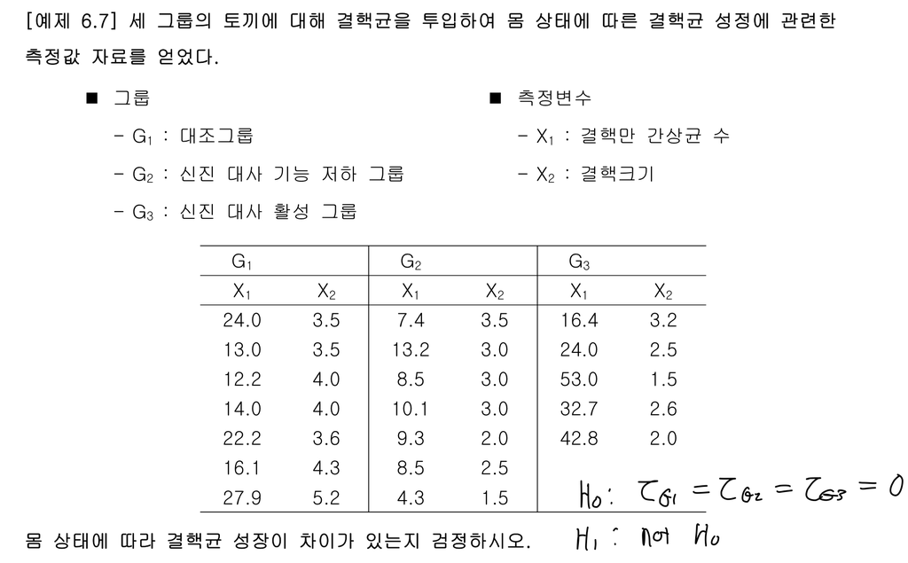

### Loading data

```r
rabbit <- read.csv("/Users/jaeyonglee/Documents/College/Bachelor/uniwise/MVA/R/data/ch6/rabbit.csv", header=TRUE, skip=4)
rabbit
```

| G | X1 | X2 |
| --- | --- | --- |
| 1 | 24.0 | 3.5 |
| 1 | 13.0 | 3.5 |
| 1 | 12.2 | 4.0 |
| 1 | 14.0 | 4.0 |
| 1 | 22.2 | 3.6 |
| 1 | 16.1 | 4.3 |
| 1 | 27.9 | 5.2 |
| 2 | 7.4 | 3.5 |
| 2 | 13.2 | 3.0 |
| 2 | 8.5 | 3.0 |

[output cut: 9 more lines]

### Data preprocessing

```r
rabbit$G <- factor(rabbit$G, labels=paste("G",1:3,sep=""))  # 이렇게하면 G1, ..., G3 으로 factor화할 수 있음
rabbit
```

| G | X1 | X2 |
| --- | --- | --- |
| G1 | 24.0 | 3.5 |
| G1 | 13.0 | 3.5 |
| G1 | 12.2 | 4.0 |
| G1 | 14.0 | 4.0 |
| G1 | 22.2 | 3.6 |
| G1 | 16.1 | 4.3 |
| G1 | 27.9 | 5.2 |
| G2 | 7.4 | 3.5 |
| G2 | 13.2 | 3.0 |
| G2 | 8.5 | 3.0 |

[output cut: 9 more lines]

### 그룹1 평균벡터

```r
colMeans(rabbit[(rabbit$G=="G1"), -1])  # 첫번째 열은 집단을 나타내는 범주형 변수이므로 빼주자
```

```
       X1        X2
18.485714  4.014286
```

### 그룹1 공분산행렬

```r
cov(rabbit[(rabbit$G=="G1"), -1])  # 첫번째 열은 집단을 나타내는 범주형 변수이므로 빼주자
```

```
          X1        X2
X1 38.041429 1.5135714
X2  1.513571 0.3647619
```

### 그룹2 평균벡터

```r
colMeans(rabbit[(rabbit$G=="G2"), -1])  # 첫번째 열은 집단을 나타내는 범주형 변수이므로 빼주자
```

```
      X1       X2
8.757143 2.642857
```

### 그룹2 공분산행렬

```r
cov(rabbit[(rabbit$G=="G2"), -1])  # 첫번째 열은 집단을 나타내는 범주형 변수이므로 빼주자
```

```
          X1        X2
X1 7.2795238 0.9321429
X2 0.9321429 0.4761905
```

### 그룹3 평균벡터

```r
colMeans(rabbit[(rabbit$G=="G3"), -1])  # 첫번째 열은 집단을 나타내는 범주형 변수이므로 빼주자
```

```
   X1    X2
33.78  2.36
```

### 그룹3 공분산행렬

```r
cov(rabbit[(rabbit$G=="G3"), -1])  # 첫번째 열은 집단을 나타내는 범주형 변수이므로 빼주자
```

```
        X1     X2
X1 212.412 -9.001
X2  -9.001  0.413
```

### X1과 X2 산점도

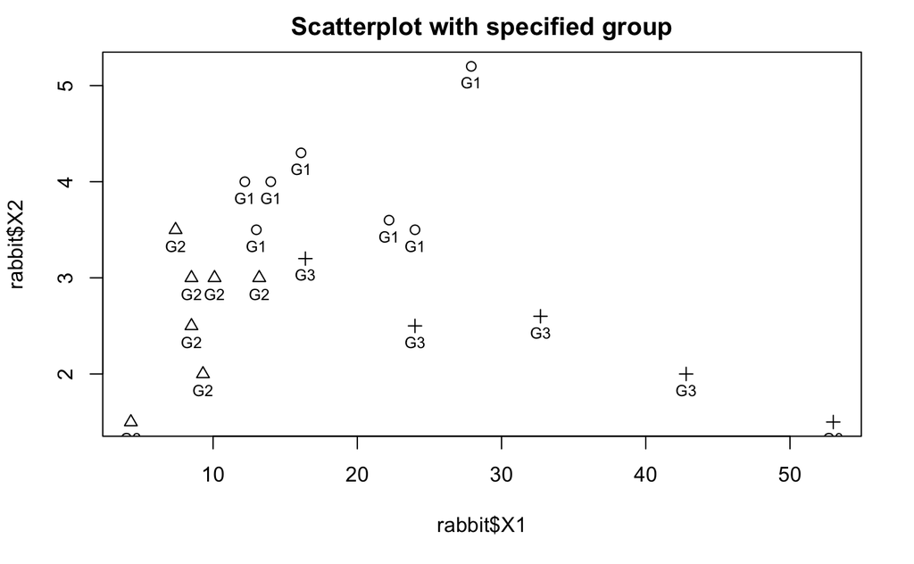

```r
plot(rabbit$X1, rabbit$X2, pch=as.numeric(rabbit$G), main="Scatterplot with specified group")
text(rabbit$X1, rabbit$X2, labels=rabbit$G, pos=1, cex=0.75)
```

#### 산점도를 보면 그룹별 영역이 확실히 구분되는 것을 볼 수 있다. 즉, 그룹간의 평균차이가 있음을 짐작해볼 수 있다.

### Wilk’s lambda 검정통계량과 근사 F검정통계량

```r
X <- cbind(rabbit$X1, rabbit$X2)  # 자료행렬로 변환
maov <- manova(X~rabbit$G)
summary(maov, test="Wilks")
```

```
          Df  Wilks approx F num Df den Df    Pr(>F)
rabbit$G   2 0.1495   11.897      4     30 6.582e-06 ***
Residuals 16
---
Signif. codes:  0 ‘***’ 0.001 ‘**’ 0.01 ‘*’ 0.05 ‘.’ 0.1 ‘ ’ 1
```

#### 여기서 approx F가 근사 검정통계량이고 여기의 유의확률도 이 근사 F분포에 의한 것이다.

#### 유의확률이 유의수준 0.05보다 작으므로 귀무가설을 기각한다. 즉, 집단별 평균벡터에 차이가 있음을 알 수 있다.

### Pillai 검정통계량과 근사 F검정통계량

```r
summary(maov, test="Pillai")
```

```
          Df Pillai approx F num Df den Df    Pr(>F)
rabbit$G   2 1.2259   12.668      4     32 2.744e-06 ***
Residuals 16
---
Signif. codes:  0 ‘***’ 0.001 ‘**’ 0.01 ‘*’ 0.05 ‘.’ 0.1 ‘ ’ 1
```

### 다변량 분산분석 - Hotelling-Lawley 검정통계량과 근사 F검정통계량

```r
summary(maov, test="Hotelling")
```

```
          Df Hotelling-Lawley approx F num Df den Df    Pr(>F)
rabbit$G   2           3.1783   11.124      4     28 1.577e-05 ***
Residuals 16
---
Signif. codes:  0 ‘***’ 0.001 ‘**’ 0.01 ‘*’ 0.05 ‘.’ 0.1 ‘ ’ 1
```

### Roy의 최대근(greatest root) 검정통계량과 근사 F검정통계량

```r
summary(maov, test="Roy")
```

```
          Df    Roy approx F num Df den Df    Pr(>F)
rabbit$G   2 1.7098   13.679      2     16 0.0003439 ***
Residuals 16
---
Signif. codes:  0 ‘***’ 0.001 ‘**’ 0.01 ‘*’ 0.05 ‘.’ 0.1 ‘ ’ 1
```

## 공분산행렬의 동일성 검정

#### (예제2 데이터)

#### H0: 모든 집단의 공분산행렬이 같다 vs. H1: 적어도 하나의 공분산행렬이 다르다

### 처리별 표본의 수

```r
n <- table(rabbit$G)
n
```

```
G1 G2 G3
 7  7  5
```

### vi = ni - 1

```r
v <- n - 1
v
```

```
G1 G2 G3
 6  6  4
```

### 전체 자료의 수

```r
N <- sum(n)
N
```

```
[1] 19
```

### 처리의 수

```r
g <- length(n)
g
```

```
[1] 3
```

### 변수의 수

```r
p <- dim(rabbit[,-1])[2]
p
```

```
[1] 2
```

### 처리별 데이터 나누기

#### 처리1의 데이터

```r
G1.rs <- rabbit[rabbit$G=="G1", -1]
G1.rs
```

|  | X1 | X2 |
| --- | --- | --- |
| 1 | 24.0 | 3.5 |
| 2 | 13.0 | 3.5 |
| 3 | 12.2 | 4.0 |
| 4 | 14.0 | 4.0 |
| 5 | 22.2 | 3.6 |
| 6 | 16.1 | 4.3 |
| 7 | 27.9 | 5.2 |

#### 처리2의 데이터

```r
G2.rs <- rabbit[rabbit$G=="G2", -1]
G2.rs
```

|  | X1 | X2 |
| --- | --- | --- |
| 8 | 7.4 | 3.5 |
| 9 | 13.2 | 3.0 |
| 10 | 8.5 | 3.0 |
| 11 | 10.1 | 3.0 |
| 12 | 9.3 | 2.0 |
| 13 | 8.5 | 2.5 |
| 14 | 4.3 | 1.5 |

#### 처리3의 데이터

```r
G3.rs <- rabbit[rabbit$G=="G3", -1]
G3.rs
```

|  | X1 | X2 |
| --- | --- | --- |
| 15 | 16.4 | 3.2 |
| 16 | 24.0 | 2.5 |
| 17 | 53.0 | 1.5 |
| 18 | 32.7 | 2.6 |
| 19 | 42.8 | 2.0 |

### 처리별 표본공분산행렬과 그의 행렬식

#### 처리1

```r
S1 <- cov(G1.rs)  # 표본공분산행렬
S1
```

```
          X1        X2
X1 38.041429 1.5135714
X2  1.513571 0.3647619
```

```r
detS1 <- det(S1)  # 표본공분산행렬의 행렬식
detS1
```

```
[1] 11.58517
```

#### 처리2

```r
S2 <- cov(G2.rs)  # 표본공분산행렬
S2
```

```
          X1        X2
X1 7.2795238 0.9321429
X2 0.9321429 0.4761905
```

```r
detS2 <- det(S2)  # 표본공분산행렬의 행렬식
detS2
```

```
[1] 2.59755
```

#### 처리3

```r
S3 <- cov(G3.rs)  # 표본공분산행렬
S3
```

```
        X1     X2
X1 212.412 -9.001
X2  -9.001  0.413
```

```r
detS3 <- det(S3)  # 표본공분산행렬의 행렬식
detS3
```

```
[1] 6.708155
```

### 합동표본공분산행렬과 그의 행렬식

```r
Spl <- (v[1]*S1 + v[2]*S2 + v[3]*S3)/sum(v)
Spl
```

```
          X1         X2
X1 70.098357 -1.3331071
X2 -1.333107  0.4186071
```

```r
detSpl <- det(Spl)
detSpl
```

```
[1] 27.5665
```

### M 값

```r
M <- ((detS1/detSpl)^(v[1]/2))*((detS2/detSpl)^(v[2]/2))*((detS3/detSpl)^(v[3]/2))
M
```

```
          G1
3.677491e-06
```

#### 여기서 출력되는 G1은 그냥 무시하셈

### c1 값

```r
c1 <- (sum(1/v)-(1/sum(v)))*((2*p^2+3*p-1)/(6*(p+1)*(g-1)))
c1
```

```
[1] 0.1880787
```

### Box의 M-검정: u 검정통계량

```r
u <- (-2*(1-c1)*log(M))
u
```

```
     G1
20.3196
```

### 기각역

```r
alpha <- 0.05

qchisq(1-alpha, (g-1)*p*(p+1)/2)
```

```
[1] 12.59159
```

#### 유의수준 5%에서 검정통계량이 기각역에 있으므로 귀무가설을 기각한다. 즉, 모든 집단의 공분산행렬이 같다고 할 수 없다.

### 유의확률

```r
pchisq(u, (g-1)*p*(p+1)/2, lower.tail=FALSE)
```

```
         G1
0.002428911
```

#### 유의확률이 유의수준 0.05보다 작으므로 귀무가설을 기각한다. 즉, 모든 집단의 공분산행렬이 같다고 할 수 없다.

## 일변량 분산분석과 사후검정

#### (예제2 데이터)

### 집단별 X1 평균

```r
tapply(rabbit$X1, rabbit$G, mean)
```

```
       G1        G2        G3
18.485714  8.757143 33.780000
```

### 집단별 X1 분산

```r
tapply(rabbit$X1, rabbit$G, var)
```

```
        G1         G2         G3
 38.041429   7.279524 212.412000
```

### 집단별 X2 평균

```r
tapply(rabbit$X2, rabbit$G, mean)
```

```
      G1       G2       G3
4.014286 2.642857 2.360000
```

### 집단별 X2 분산

```r
tapply(rabbit$X2, rabbit$G, var)
```

```
       G1        G2        G3
0.3647619 0.4761905 0.4130000
```

### X1의 일변량 분산분석

```r
aov.X1 <- aov(rabbit$X1 ~ rabbit$G)
summary(aov.X1)
```

```
            Df Sum Sq Mean Sq F value   Pr(>F)
rabbit$G     2   1828   914.2   13.04 0.000437 ***
Residuals   16   1122    70.1
---
Signif. codes:  0 ‘***’ 0.001 ‘**’ 0.01 ‘*’ 0.05 ‘.’ 0.1 ‘ ’ 1
```

#### 여기서 rabbit$G가 처리를 나타내는거임

#### 유의확률이 유의수준 0.05보다 작으므로 귀무가설을 기각한다. 즉, 적어도 하나의 처리별 평균에 차이가 있다고 할 수 있다.

### X1의 Tukey’s HSD 사후검정

```r
TukeyHSD(aov.X1)
```

```
  Tukey multiple comparisons of means
    95% family-wise confidence level

Fit: aov(formula = rabbit$X1 ~ rabbit$G)

$`rabbit$G`
           diff       lwr       upr     p adj
G2-G1 -9.728571 -21.27627  1.819123 0.1065031
G3-G1 15.294286   2.64442 27.944151 0.0171551
G3-G2 25.022857  12.37299 37.672723 0.0002960
```

#### lwr와 upr가 95% 신뢰구간을 나타낸다.

#### 이 신뢰구간에 0이 포함될 수 있다면 이는 그 두 집단간 평균에 차이가 없다고 할 수 있다.

#### 신뢰구간에 0이 포함되지 않은 경우, 그 두 집단간 평균에 차이가 있다고 할 수 있다.

#### 여기서 p adj가 유의확률을 나타낸다. (H0: 두 집단간 평균에 차이가 없다. H1: Not H0)

#### 결론적으로, 유의수준 5%에서 G2와 G1간 평균에는 차이가 없고, G3와 G1, G3와 G2간 평균에 차이가 있다고 할 수 있다.

### X1의 LSD 사후검정

```r
pairwise.t.test(rabbit$X1, rabbit$G)
```

```
    Pairwise comparisons using t tests with pooled SD

data:  rabbit$X1 and rabbit$G

   G1      G2
G2 0.04507 -
G3 0.01320 0.00032

P value adjustment method: holm
```

#### 여기서 주는 행렬이 각 집단 간의 평균 차이에 대한 검정의 유의확률이다. (H0: 두 집단간의 평균 차이가 없다. H1: Not H0)

#### 즉, 유의수준 5%에서 모든 집단 간의 평균에 차이가 있다고 할 수 있다.

#### 이렇게 사후검정 방법에 따라서도 결과에 차이가 있을 수 있다.

### X1의 평균그래프

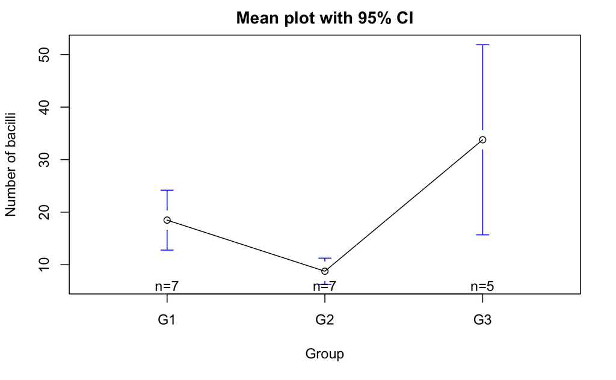

```r
library(gplots)
plotmeans(rabbit$X1~rabbit$G, xlab="Group", ylab="Number of bacilli", main=c("Mean plot with 95% CI"))
```

#### 파란선은 각 집단별 평균의 신뢰구간임

### X1의 잔차도표

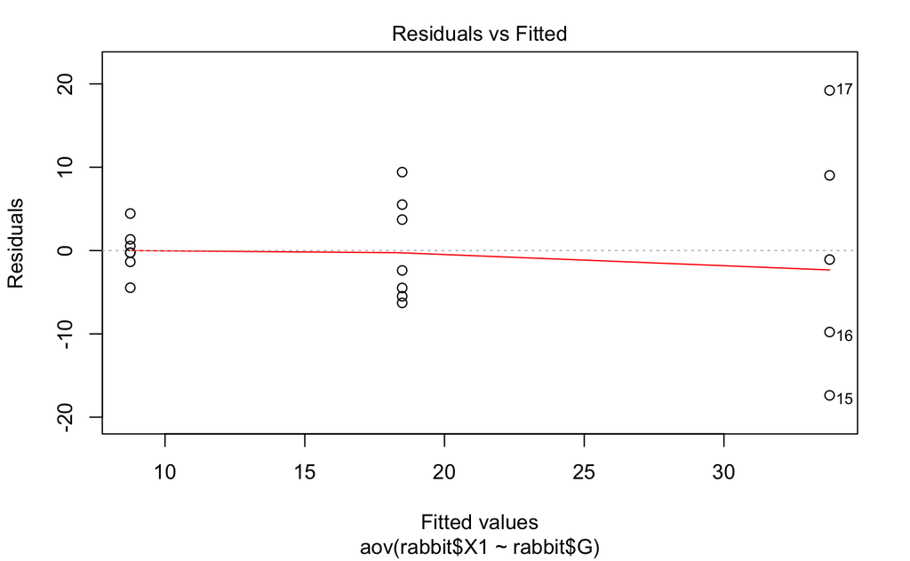

```r
plot(aov.X1, which=1)
```

### X1의 Q-Q plot

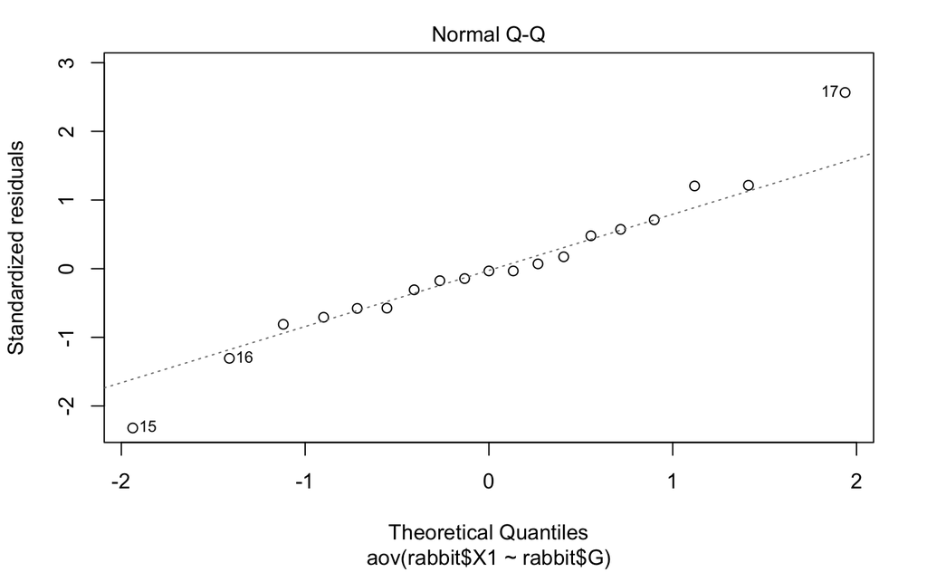

```r
plot(aov.X1, which=2)
```

#### outlier 같아 보이는 점들의 인덱스가 표시되어있는 것도 볼 수 있다.

### X2의 일변량 분산분석

```r
aov.X2 <- aov(rabbit$X2 ~ rabbit$G)
summary(aov.X2)
```

```
            Df Sum Sq Mean Sq F value   Pr(>F)
rabbit$G     2 10.039   5.020   11.99 0.000658 ***
Residuals   16  6.698   0.419
---
Signif. codes:  0 ‘***’ 0.001 ‘**’ 0.01 ‘*’ 0.05 ‘.’ 0.1 ‘ ’ 1
```

#### 여기서 rabbit$G가 처리를 나타내는거임

#### 유의확률이 유의수준 0.05보다 작으므로 귀무가설을 기각한다. 즉, 적어도 하나의 처리별 평균에 차이가 있다고 할 수 있다.

```r
TukeyHSD(aov.X2)
```

```
  Tukey multiple comparisons of means
    95% family-wise confidence level

Fit: aov(formula = rabbit$X2 ~ rabbit$G)

$`rabbit$G`
            diff       lwr        upr     p adj
G2-G1 -1.3714286 -2.263798 -0.4790591 0.0030071
G3-G1 -1.6542857 -2.631827 -0.6767440 0.0013155
G3-G2 -0.2828571 -1.260399  0.6946846 0.7399202
```

#### lwr와 upr가 95% 신뢰구간을 나타낸다.

#### 이 신뢰구간에 0이 포함될 수 있다면 이는 그 두 집단간 평균에 차이가 없다고 할 수 있다.

#### 신뢰구간에 0이 포함되지 않은 경우, 그 두 집단간 평균에 차이가 있다고 할 수 있다.

#### 여기서 p adj가 유의확률을 나타낸다. (H0: 두 집단간 평균에 차이가 없다. H1: Not H0)

#### 결론적으로, 유의수준 5%에서 G3와 G2간 평균에는 차이가 없고, G2와 G1, G3와 G1간 평균에 차이가 있다고 할 수 있다.

### X2의 LSD 사후검정

```r
pairwise.t.test(rabbit$X2, rabbit$G)
```

```
    Pairwise comparisons using t tests with pooled SD

data:  rabbit$X2 and rabbit$G

   G1     G2
G2 0.0022 -
G3 0.0014 0.4661

P value adjustment method: holm
```

#### 여기서 주는 행렬이 각 집단 간의 평균 차이에 대한 검정의 유의확률이다. (H0: 두 집단간의 평균 차이가 없다. H1: Not H0)

#### 즉, 유의수준 5%에서 G2와 G3간 평균에 차이가 있다고 할 수 없다.

### X2의 평균그래프

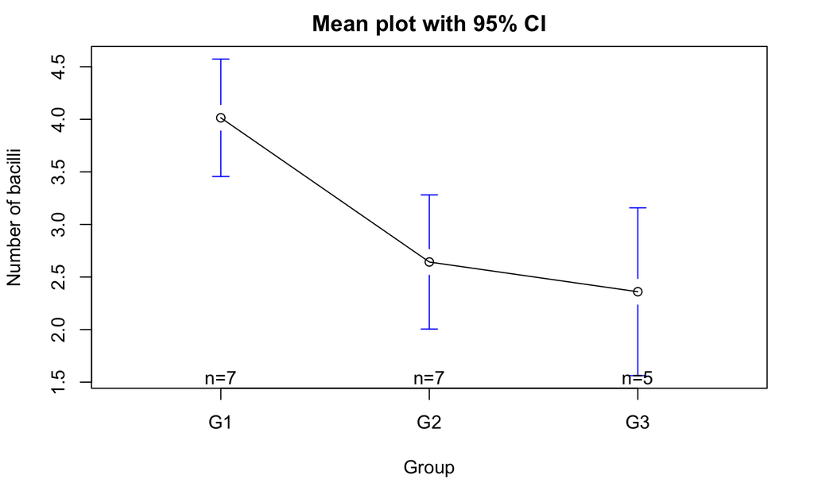

```r
library(gplots)
plotmeans(rabbit$X2~rabbit$G, xlab="Group", ylab="Number of bacilli", main=c("Mean plot with 95% CI"))
```

#### 파란선은 각 집단별 평균의 신뢰구간임

### X2의 잔차도표

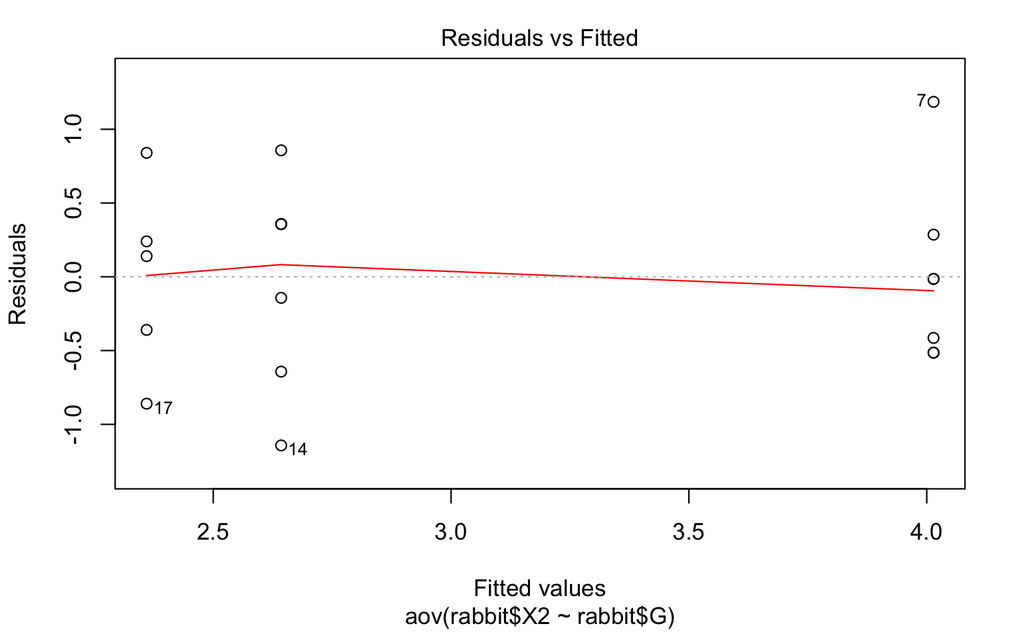

```r
plot(aov.X2, which=1)
```

### X2의 Q-Q plot

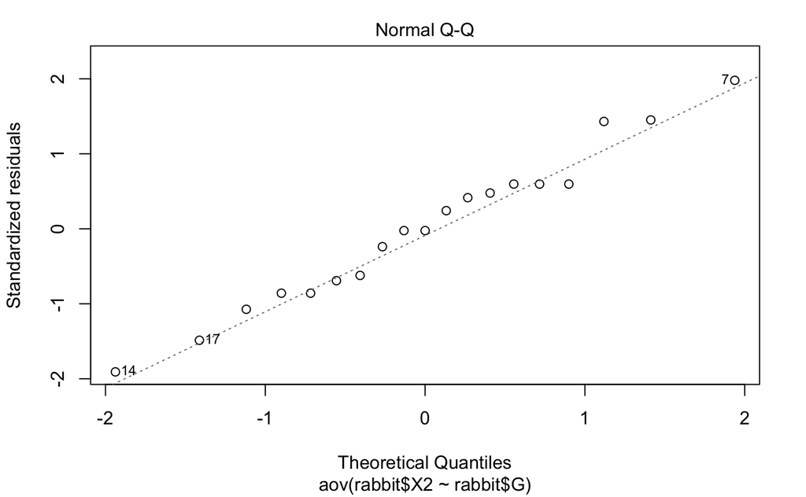

```r
plot(aov.X2, which=2)
```

#### 정규성을 크게 벗어나 보이진 않는다.

# 이원배치 다변량 분산분석 - 예제3

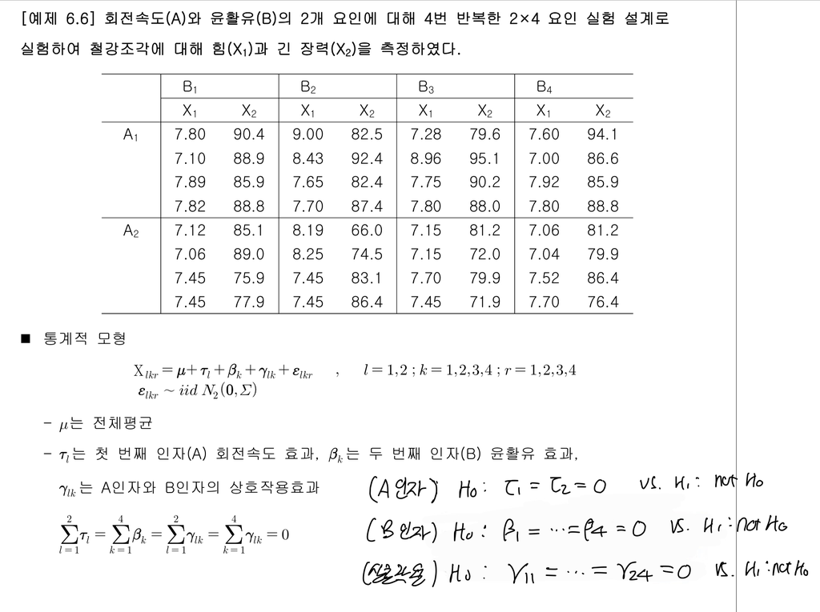

### Loading data

```r
steel <- read.table("/Users/jaeyonglee/Documents/College/Bachelor/uniwise/MVA/R/data/ch6/steel.txt", header=TRUE, sep="\t", skip=6)
steel
```

| A | B | R | X1 | X2 |
| --- | --- | --- | --- | --- |
| 1 | 1 | 1 | 7.80 | 90.4 |
| 1 | 1 | 2 | 7.10 | 88.9 |
| 1 | 1 | 3 | 7.89 | 85.9 |
| 1 | 1 | 4 | 7.82 | 88.8 |
| 1 | 2 | 1 | 9.00 | 82.5 |
| 1 | 2 | 2 | 8.43 | 92.4 |
| 1 | 2 | 3 | 7.65 | 82.4 |
| 1 | 2 | 4 | 7.70 | 87.4 |
| 1 | 3 | 1 | 7.28 | 79.6 |
| 1 | 3 | 2 | 8.96 | 95.1 |

[output cut: 22 more lines]

### A요인 처리별 표본의 수

```r
A.n <- table(steel$A)
A.n
```

```
 1  2
16 16
```

### B요인 처리별 표본의 수

```r
B.n <- table(steel$B)
B.n
```

```
1 2 3 4
8 8 8 8
```

### A요인 처리수

```r
g <- length(A.n)
g
```

```
[1] 2
```

### B요인 처리수

```r
b <- length(B.n)
b
```

```
[1] 4
```

### 반복수

```r
n <- max(steel$R)
n
```

```
[1] 4
```

### 전체 자료의 수

```r
N <- dim(steel)[1]
N
```

```
[1] 32
```

### 변수의 수

```r
p <- dim(steel[,c(4,5)])[2]   # X1, X2가 변수의 개수임
p
```

```
[1] 2
```

### A인자 평균행렬

```r
X <- as.matrix(steel)  # 행렬계산을 위해 데이터를 행렬로 변환
bar.A <- aggregate(X[,4:5]~X[,1], FUN=mean)[,-1]
# 여기서 X[,4:5]가 X1,X2를 나타내고 X[,1]이 첫번째 열인 A처리의 범주형 변수임
# [,-1]로 A처리를 나타내는 범주형 변수를 빼줌
bar.A <- as.matrix(bar.A)  # 행렬계산을 위해 평균행렬 행렬변환
bar.A
```

```
           X1      X2
[1,] 7.837500 87.9375
[2,] 7.449375 79.1750
```

### B인자 평균행렬

```r
bar.B <- aggregate(X[,4:5]~X[,2], FUN=mean)[,-1]
# 여기서 X[,4:5]가 X1,X2를 나타내고 X[,2]이 두번째 열인 B처리의 범주형 변수임
# [,-1]로 B처리를 나타내는 범주형 변수를 빼줌
bar.B <- as.matrix(bar.B)  # 행렬계산을 위해 평균행렬 행렬변환
bar.B
```

```
          X1      X2
[1,] 7.46125 85.2375
[2,] 8.01500 81.8375
[3,] 7.65500 82.2375
[4,] 7.44250 84.9125
```

### A인자와 B인자의 조합 평균행렬

```r
bar.AB <- aggregate(X[,4:5]~X[,2]+X[,1], FUN=mean)[,c(-1,-2)]
# 여기서 X[,4:5]가 X1,X2를 나타내고 X[,2]+X[,1]이 A인자와 B인자의 조합의 범주형 변수들임
# 주의! 여기서는 B+A 순으로 범주형 변수를 제시했다. 이들의 순서가 바뀌면 나오는 행렬의 요소들의 순서도 바뀌게 된다.
# [,c(-1,-2)]로 A와 B처리의 조합을 나타내는 범주형 변수들을 빼줌
bar.AB <- as.matrix(bar.AB)  # 행렬계산을 위해 평균행렬 행렬변환
bar.AB
```

```
         X1     X2
[1,] 7.6525 88.500
[2,] 8.1950 86.175
[3,] 7.9475 88.225
[4,] 7.5550 88.850
[5,] 7.2700 81.975
[6,] 7.8350 77.500
[7,] 7.3625 76.250
[8,] 7.3300 80.975
```

### 전체 평균행렬

```r
bar <- colMeans(X[,4:5])
bar
```

```
       X1        X2
 7.643438 83.556250
```

### A인자 제곱합과 교차곱행렬

```r
SSPA <- matrix(rep(0,p^2), ncol=p)  # pxp 행렬이므로 행렬 원소가 p^2개가 필요
for(i in 1:g){
  EQ <- bar.A[i,]-bar
  SSPA <- SSPA + b*n*(EQ %*% t(EQ))
}
SSPA
```

```
            X1        X2
[1,]  1.205128  27.20756
[2,] 27.207563 614.25125
```

### B인자 제곱합과 교차곱행렬

```r
SSPB <- matrix(rep(0,p^2), ncol=p)
for(i in 1:b){
  EQ <- bar.B[i,]-bar
  SSPB <- SSPB + g*n*(EQ %*% t(EQ))
}
SSPB
```

```
            X1        X2
[1,]  1.694084 -9.861562
[2,] -9.861562 74.873750
```

### 상호작용(AB) 제곱합과 교차곱행렬

```r
SSPAB <- matrix(rep(0,p^2), ncol=p)
  for(i in 1:g){
    for(j in 1:b){
      EQ <- bar.AB[(i-1)*b+j,]-bar.A[i,]-bar.B[j,]+bar  # 인덱스 접근에 유의하자, 좀 어렵다
      SSPAB <- SSPAB + n*(EQ %*% t(EQ))
    }
  }
SSPAB
```

```
            X1        X2
[1,] 0.1323844  1.584562
[2,] 1.5845625 32.243750
```

### 오차 제곱합과 교차곱행렬

```r
SSPE <- matrix(rep(0,p^2), ncol=p)
  for(i in 1:N){
    EQ <- X[i,4:5]-bar.AB[((i-1)%/%4)+1,]  # X[i,4:5]로 X1,X2의 i번째 행을 접근
    # 얘는 인덱스를 이렇게 좀 특이하게 접근하는듯? 4가 쓰인 이유는 R(반복수)이 4임
    SSPE <- SSPE + (EQ %*% t(EQ))
  }
SSPE
```

```
            X1        X2
[1,]  4.896525  -1.88975
[2,] -1.889750 736.39000
```

### 총 제곱합과 교차곱행렬

```r
SSPCOR <- matrix(rep(0,p^2), ncol=p)
  for(i in 1:N){
    EQ <- X[i,4:5]-bar  # X[i,4:5]로 X1,X2의 i번째 행을 접근
    SSPCOR <- SSPCOR + (EQ %*% t(EQ))
  }
SSPCOR
```

```
            X1         X2
[1,]  7.928122   17.04081
[2,] 17.040812 1457.75875
```

### 요인별 자유도

```r
SSPdf <- c(g-1, b-1, (g-1)*(b-1), g*b*(n-1), g*b*n-1)
names(SSPdf) <- c("A", "B", "AB", "E", "COR")
SSPdf
```

```
  A   B  AB   E COR
  1   3   3  24  31
```

### A인자의 Wilk’s lambda 검정통계량

```r
lambda.A <- det(SSPE)/det(SSPA+SSPE)
lambda.A
```

```
[1] 0.4739616
```

### A인자의 Wilk’s lambda 근사 검정통계량

```r
lambda.A.approx <- (-((g*b*(n-1))-(p+1-(g-1))/2))*log(lambda.A)
lambda.A.approx
```

```
[1] 17.17246
```

### A인자에 대한 근사 기각역

```r
qchisq(1-alpha, (g-1)*p)
```

```
[1] 5.991465
```

#### 유의수준 5%에서 검정통계량이 기각역에 있으므로 귀무가설을 기각한다. 즉, A인자의 처리의 효과가 있음을 알 수 있다(A인자별 평균차이가 있다).

### A인자에 대한 유의확률

```r
pchisq(lambda.A.approx, (g-1)*p, lower.tail=FALSE)
```

```
[1] 0.0001866581
```

#### 유의확률이 유의수준 0.05보다 작으므로 귀무가설을 기각한다. 즉, A인자의 처리의 효과가 있음을 알 수 있다(A인자별 평균차이가 있다).

### B인자의 Wilk’s lambda 검정통계량

```r
lambda.B <- det(SSPE)/det(SSPB+SSPE)
lambda.B
```

```
[1] 0.6915795
```

### B인자의 Wilk’s lambda 근사 검정통계량

```r
lambda.B.approx <- (-((g*b*(n-1))-(p+1-(b-1))/2))*log(lambda.B)
lambda.B.approx
```

```
[1] 8.850654
```

### B인자에 대한 근사 기각역

```r
qchisq(1-alpha, (b-1)*p)
```

```
[1] 12.59159
```

#### 유의수준 5%에서 검정통계량이 기각역에 있지 않으므로 귀무가설을 기각하지 못한다. 즉, B인자의 처리의 효과가 있다고 할 수 없다(B인자별 평균차이가 없다).

### B인자에 대한 유의확률

```r
pchisq(lambda.B.approx, (b-1)*p, lower.tail=FALSE)
```

```
[1] 0.1821531
```

#### 유의확률이 유의수준 0.05보다 크므로 귀무가설을 기각하지 못한다. 즉, B인자의 처리의 효과가 있다고 할 수 없다(B인자별 평균차이가 없다).

### 상호작용(AB)의 Wilk’s lambda 검정통계량

```r
lambda.AB <- det(SSPE)/det(SSPAB+SSPE)
lambda.AB
```

```
[1] 0.9319288
```

### 상호작용(AB)의 Wilk’s lambda 근사 검정통계량

```r
lambda.AB.approx <- (-((g*b*(n-1))-(p+1-(g-1)*(b-1))/2))*log(lambda.AB)
lambda.AB.approx
```

```
[1] 1.691973
```

### 상호작용(AB)에 대한 근사 기각역

```r
qchisq(1-alpha, (g-1)*(b-1)*p)
```

```
[1] 12.59159
```

#### 유의수준 5%에서 검정통계량이 기각역에 있지 않으므로 귀무가설을 기각하지 못한다. 즉, A인자와 B인자간의 상호작용 효과가 있다고 할 수 없다.

### 상호작용(AB)에 대한 유의확률

```r
pchisq(lambda.AB.approx, (g-1)*(b-1)*p, lower.tail=FALSE)
```

```
[1] 0.9457393
```

## R의 패키지를 사용한 다변량 이원배치 분산분석

#### (예제3 데이터)

### Data preprocessing

```r
steel$A <- factor(steel$A)  # 범주형 변수의 factor화
steel$B <- factor(steel$B)
steel
```

| A | B | R | X1 | X2 |
| --- | --- | --- | --- | --- |
| 1 | 1 | 1 | 7.80 | 90.4 |
| 1 | 1 | 2 | 7.10 | 88.9 |
| 1 | 1 | 3 | 7.89 | 85.9 |
| 1 | 1 | 4 | 7.82 | 88.8 |
| 1 | 2 | 1 | 9.00 | 82.5 |
| 1 | 2 | 2 | 8.43 | 92.4 |
| 1 | 2 | 3 | 7.65 | 82.4 |
| 1 | 2 | 4 | 7.70 | 87.4 |
| 1 | 3 | 1 | 7.28 | 79.6 |
| 1 | 3 | 2 | 8.96 | 95.1 |

[output cut: 22 more lines]

### Wilk’s lambda 검정통계량과 그의 근사 F분포

```r
X <- cbind(steel$X1, steel$X2)  # 자료를 행렬로 변환
maov <- manova(X~steel$A+steel$B+steel$A:steel$B)  # 또는 X~A*B로 더 간편히 할 수 있다
summary(maov,test="Wilks")
```

```
                Df   Wilks approx F num Df den Df    Pr(>F)
steel$A          1 0.47396  12.7636      2     23 0.0001867 ***
steel$B          3 0.69158   1.5524      6     46 0.1827862
steel$A:steel$B  3 0.93193   0.2751      6     46 0.9458304
Residuals       24
---
Signif. codes:  0 ‘***’ 0.001 ‘**’ 0.01 ‘*’ 0.05 ‘.’ 0.1 ‘ ’ 1
```

#### A인자, B인자, 상호작용(AB)에 대해 가설검정을 하면 된다.

### Pillai 검정통계량과 그의 근사 F분포

```r
summary(maov,test="Pillai")
```

```
                Df  Pillai approx F num Df den Df    Pr(>F)
steel$A          1 0.52604  12.7636      2     23 0.0001867 ***
steel$B          3 0.31410   1.4905      6     48 0.2015936
steel$A:steel$B  3 0.06853   0.2838      6     48 0.9418287
Residuals       24
---
Signif. codes:  0 ‘***’ 0.001 ‘**’ 0.01 ‘*’ 0.05 ‘.’ 0.1 ‘ ’ 1
```

### Hotelling-Lawley 검정통계량과 그의 근사 F분포

```r
summary(maov,test="Hotelling")
```

```
                Df Hotelling-Lawley approx F num Df den Df    Pr(>F)
steel$A          1          1.10988  12.7636      2     23 0.0001867 ***
steel$B          3          0.43775   1.6051      6     44 0.1684454
steel$A:steel$B  3          0.07256   0.2660      6     44 0.9498087
Residuals       24
---
Signif. codes:  0 ‘***’ 0.001 ‘**’ 0.01 ‘*’ 0.05 ‘.’ 0.1 ‘ ’ 1
```

### Roy의 최대근 검정통계량과 그의 근사 F분포

```r
summary(maov,test="Roy")
```

```
                Df     Roy approx F num Df den Df    Pr(>F)
steel$A          1 1.10988  12.7636      2     23 0.0001867 ***
steel$B          3 0.41810   3.3448      3     24 0.0359080 *
steel$A:steel$B  3 0.06505   0.5204      3     24 0.6722819
Residuals       24
---
Signif. codes:  0 ‘***’ 0.001 ‘**’ 0.01 ‘*’ 0.05 ‘.’ 0.1 ‘ ’ 1
```

#### Roy의 근사 분포로는 B인자도 유의하게 나왔다. 근데 나머지 통계량들에서는 그렇지 않게 나왔으므로 그렇게 유의해 보이진 않는다.

## 일변량 이원배치분산분석

#### (예제3 데이터)

### X1의 일변량 이원배치분산분석

```r
aov.X1 <- aov(steel$X1 ~ steel$A+steel$B+steel$A:steel$B)  # 또는 X1~A*B
summary(aov.X1)
```

```
                Df Sum Sq Mean Sq F value Pr(>F)
steel$A          1  1.205  1.2051   5.907 0.0229 *
steel$B          3  1.694  0.5647   2.768 0.0637 .
steel$A:steel$B  3  0.132  0.0441   0.216 0.8841
Residuals       24  4.897  0.2040
---
Signif. codes:  0 ‘***’ 0.001 ‘**’ 0.01 ‘*’ 0.05 ‘.’ 0.1 ‘ ’ 1
```

#### A인자, B인자, 상호작용(AB)에 대해 가설검정을 하면 된다.

### X2의 일변량 이원배치분산분석

```r
aov.X2 <- aov(steel$X2 ~ steel$A+steel$B+steel$A:steel$B)  # 또는 X1~A*B
summary(aov.X2)
```

```
                Df Sum Sq Mean Sq F value   Pr(>F)
steel$A          1  614.3   614.3  20.019 0.000158 ***
steel$B          3   74.9    25.0   0.813 0.499018
steel$A:steel$B  3   32.2    10.7   0.350 0.789277
Residuals       24  736.4    30.7
---
Signif. codes:  0 ‘***’ 0.001 ‘**’ 0.01 ‘*’ 0.05 ‘.’ 0.1 ‘ ’ 1
```

#### A인자, B인자, 상호작용(AB)에 대해 가설검정을 하면 된다.

### X1의 이원배치 상호작용 Plot

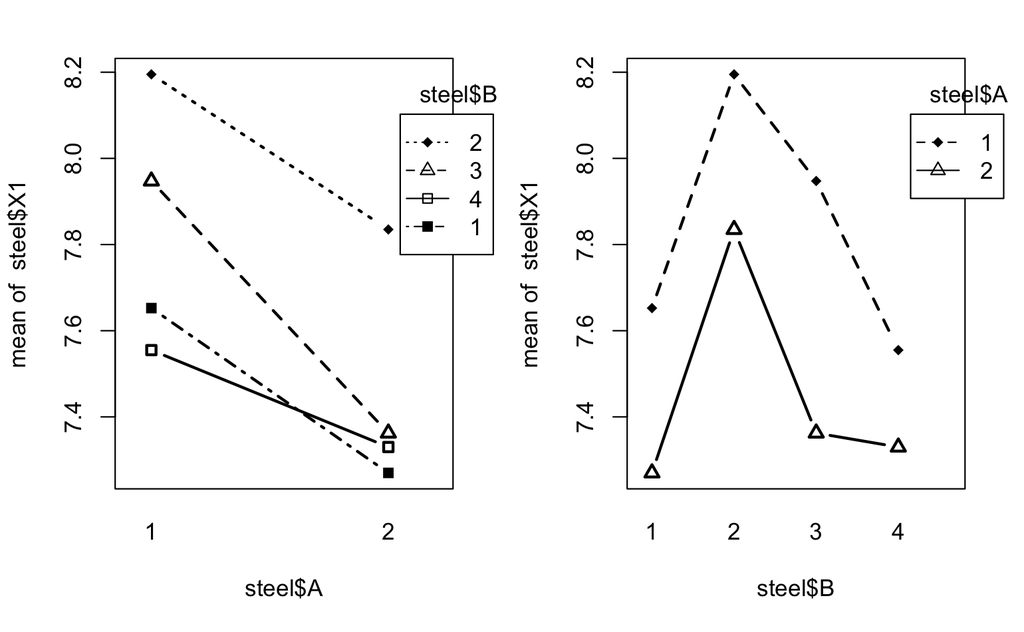

```r
layout(matrix(1:2,ncol=2))
interaction.plot(steel$A,steel$B,steel$X1, type="b",pch=c(15,18,24,22),lwd=2,leg.bty="o",leg.bg="white")
interaction.plot(steel$B,steel$A,steel$X1,type="b",pch=c(18,24),lwd=2,leg.bty="o",leg.bg="white")
```

#### 첫번째 그래프에서 A 수준은 x축의 값들이고 B수준은 점모양으로 나타나있다. 두번째 그래프에서 B 수준은 x축의 값들이고 A수준은 점모양으로 나타나있다.

#### 상호작용 효과를 보려면 이 선들이 교차되는 것에 주목해야하는데, 여기선 두 그래프에서 교차되는 선들이 별로 없고 그 정도도 크지 않기 때문에 상호작용 효과가 별로 없다고 볼 수 있다.

### X2의 이원배치 상호작용 Plot

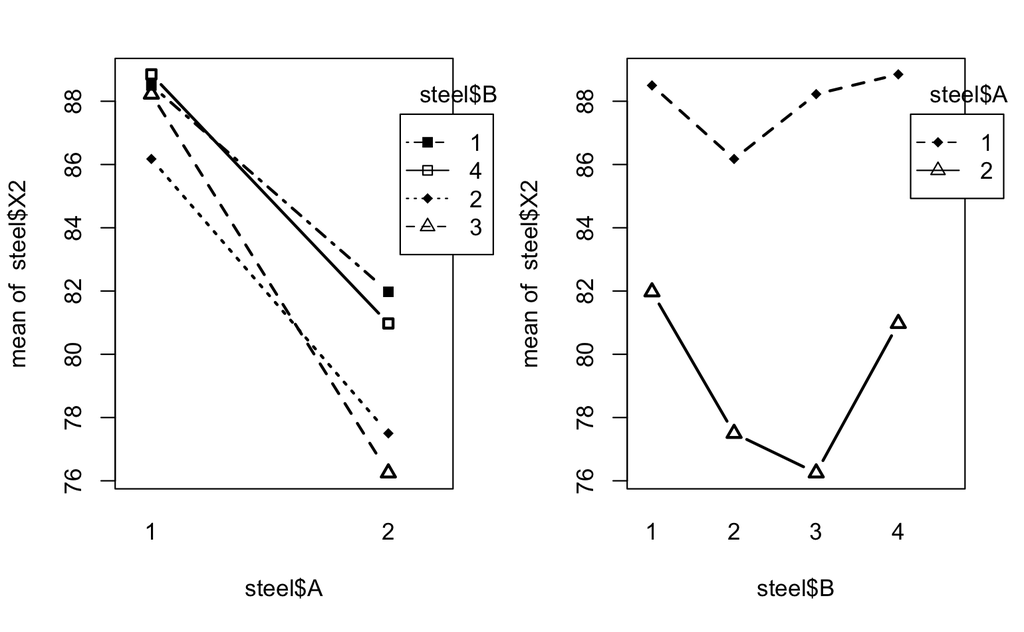

```r
layout(matrix(1:2,ncol=2))
interaction.plot(steel$A,steel$B,steel$X2, type="b",pch=c(15,18,24,22),lwd=2,leg.bty="o",leg.bg="white")
interaction.plot(steel$B,steel$A,steel$X2,type="b",pch=c(18,24),lwd=2,leg.bty="o",leg.bg="white")
```

#### 여기서도 교차되는 선들이 좀 있긴 한데 정도가 크지 않아 상호작용 효과가 없다고 볼 수 있다.